# Chapter 4

## Solutions

### Q1.

> Using a little bit of algebra, prove that (4.2) is equivalent to (4.3). In other words, the logistic function representation and logit representation for the logistic regression model are equivalent.

$$p(X) = \frac{e^{\beta_0 + \beta_1 X}}{1 + e^{\beta_0 + \beta_1 X}} \Leftrightarrow e^{\beta_0 + \beta_1 X}(1 - p(X)) = p(X)$$

which is equivalent to
$$\frac{p(X)}{1 - p(X)} = e^{\beta_0 + \beta_1 X}.$$
*

### Q2. It was stated in the text that classifying an observation to the class for which (4.12) is largest is equivalent to classifying an observation to the class for which (4.13) is largest. Prove that this is the case. In other words, under the assumption that the observations in the kth class are drawn from a $N(\mu_k, \sigma^2)$ distribution, the Bayes’ classifier assigns an observation to the class for which the discriminant function is maximized.

### Q3. This problem relates to the QDA model, in which the observations within each class are drawn from a normal distribution with a classspecific mean vector and a class specific covariance matrix. We consider the simple case where $p = 1$; i.e. there is only one feature. Suppose that we have $K$ classes, and that if an observation belongs to the kth class then $X$ comes from a one-dimensional normal distribution, $X \sim N(\mu_k, \sigma_k)$. Recall that the density function for the one-dimensional normal distribution is given in (4.11). Prove that in this case, the Bayes’ classifier is not linear. Argue that it is in fact quadratic.

### Q4. When the number of features p is large, there tends to be a deterioration in the performance of KNN and other local approaches that perform prediction using only observations that are near the test observation for which a prediction must be made. This phenomenon is known as the curse of dimensionality, and it ties into the fact that non-parametric approaches often perform poorly when p is large. We will now investigate this curse.

1. Suppose that we have a set of observations, each with measurements on $p = 1$ feature, $X$. We assume that $X$ is uniformly (evenly) distributed on $[0,1]$. Associated with each observation is a response value. Suppose that we wish to predict a test observation’s response using only observations that are within 10% of the range of $X$ closest to that test observation. For instance, in order to predict the response for a test observation with $X = 0.6$, we will use observations in the range $[0.55,0.65]$. On average, what fraction of the available observations will we use to make the prediction ?
2. Now suppose that we have a set of observations, each with measurements on $p = 2$ features, $X_1$ and $X_2$. We assume that $(X_1, X_2)$ are uniformly distributed on $[0,1]\times[0,1]$. We wish to predict a test observation’s response using only observations that are within 10% of the range of $X_1$ and within 10% of the range of $X_2$ closest to that test observation. For instance, in order to predict the response for a test observation with $X_1 = 0.6$ and $X_2 = 0.35$, we will use observations in the range $[0.55,0.65]$ for $X_1$ and in the range $[0.3,0.4]$ for $X_2$. On average, what fraction of the available observations will we use to make the prediction ?
3. Now suppose that we have a set of observations on $p = 100$ features. Again the observations are uniformly distributed on each feature, and again each feature ranges in value from 0 to 1. We wish to predict a test observation’s response using observations within the 10% of each feature’s range that is closest to that test observation. What fraction of the available observations will we use to make the prediction ?
4. Using your answers to parts (a)-(c), argue that a drawback of KNN when $p$ is large is that there are very few training observations “near” any given test observation.
5. Now suppose that we wish to make a prediction for a test observation by creating a p-dimensional hypercube centered around the test observation that contains, on average, 10% of the training observations. For $p = 1, 2, 100$, what is the length of each side of the hypercube ? Comment on your answer. Note: A hypercube is a generalization of a cube to an arbitrary number of dimensions. When $p = 1$, a hypercube is simply a line segment, when $p = 2$ it is a square, and when $p = 100$ it is a 100-dimensional cube.

### Q5

> We now examine the differences between LDA and QDA.
> 1. If the Bayes decision boundary is linear, do we expect LDA or QDA to perform better on the training set? On the test set?

If the actual decision boundary is linear, QDA may still perform better on the training set, but because of over-fitting may not perform better on the test set.

> 2. If the Bayes decision boundary is non-linear, do we expect LDA or QDA to perform better on the training set? On the test set?

If the decision boundary is non-linear QDA would perform better on both training and test sets

> 3. In general, as the sample size (n) increases, do we expect the test prediction accuracy of QDA relative to LDA to improve, decline,or be unchanged? Why?
> 4. True or False: Even if the Bayes decision boundary for a givenproblem is linear, we will probably achieve a superior test er-ror rate using QDA rather than LDA because QDA is flexibleenough to model a linear decision boundary. Justify your answer.

### Q6. Suppose we collect data for a group of students in a statistics class with variables $X_1 =$ hours studied, $X_2 =$ undergrad GPA, and $Y =$ receive an A. We fit a logistic regression and produce estimated coefficients, $\hat{\beta}_0 = -6$, $\hat{\beta}_1 = 0.05$, $\hat{\beta}_2 = 1$.

1. Estimate the probability that a student who studies for 40 hours and has an undergrad GPA of 3.5 gets an A in the class.

It suffices to plug in the beta values in the equation for predicted probability,
$$\hat{p}(X) = \frac{e^{-6 + 0.05X_1 + X_2}}{(1 + e^{-6 + 0.05X_1 + X_2})} = 0.3775.$$

2. How many hours would the student in part (a) need to study to have a 50% chance of getting an A in the class ?

The equation for predicted probability tells us that
$$\frac{e^{-6 + 0.05X_1 + 3.5}}{(1 + e^{-6 + 0.05X_1 + 3.5})} = 0.5,$$
which is equivalent to
$$e^{-6 + 0.05X_1 + 3.5} = 1.$$
By taking the logarithm of both sides, we get
$$X_1 = \frac{2.5}{0.05} = 50.$$

**Q7.** Suppose that we wish to predict whether a given stock will issue a dividend this year (“Yes” or “No”) based on $X$, last year’s percent profit. We examine a large number of companies and discover that the mean value of $X$ for companies that issued a dividend was $\overline{X} = 10$, while the mean for those that didn’t was $\overline{X} = 0$. In addition, the variance of $X$ for these two sets of companies was $\hat{\sigma}^2 = 36$. Finally, 80% of companies issued dividends. Assuming that $X$ follows a normal distribution, predict the probability that a company will issue a dividend this year given that its percentage return was $X = 4$ last year.

It suffices to plug in the parameters and $X$ values in the equation for $p_k(x)$. We get
$$p_1(4) = \frac{0.8 e^{-(1/72)(4 - 10)^2}}{0.8 e^{-(1/72)(4 - 10)^2} + 0.2 e^{-(1/72)(4 - 0)^2}} = 0.752;$$
so the probability that a company will issue a dividend this year given that its percentage return was $X = 4$ last year is $0.752$.

**Q8.** Suppose that we take a data set, divide it into equally-sized training and test sets, and then try out two different classification procedures. First we use logistic regression and get an error rate of 20% on the training data and 30% on the test data. Next we use 1-nearest neighbors (i.e. $K = 1$) and get an average error rate (averaged over both test and training data sets) of 18%. Based on these results, which method should we prefer to use for classification of new observations ? Why ?

In the case of KNN with $K = 1$, we have a training error rate of $0\%$ because in this case, we have
$$P(Y = j | X = x_i) = I(y_i = j)$$
which is equal to $1$ if $y_i = j$ and $0$ if not. We do not make any error on the training data within this setting, that explains the $0\%$ training error rate. However, we have an average error rate of $18\%$ wich implies a test error rate of $36\%$ for KNN which is greater than the test error rate for logistic regression of $30\%$. So, it is better to choose logistic regression because of its lower test error rate.

### Q9 This problem has to do with odds.

> 1. On average, what fraction of people with an odds of 0.37 of defaulting on their credit card payment will in fact default ?

By definition, odds, represents `prob(x)/1-prob(x)`, thus,
$$\frac{p(X)}{1 - p(X)} = 0.37,$$

OR solving for p(x) –>

$$p(X) = \frac{0.37}{1 + 0.37} = 0.27.$$

2. Suppose that an individual has a 16% chance of defaulting on her credit card payment. What are the odds that she will default ?

Conversely, we know $p(X) = 0.16$, thus,
$$\frac{p(X)}{1 - p(X)} = \frac{0.16}{1 - 0.16} = 0.19.$$

The odds that she will default is then $19\%$.*

```r
library(pacman)
# stat libs
p_load(MASS, ISLR)
# data cleaning
p_load(broom, dplyr, janitor)
# plots
p_load(corrplot, ggplot2)
```

### Q 10

### cleaning column names

```r
weekly = Weekly %>% clean_names()
```

**trend in volume**

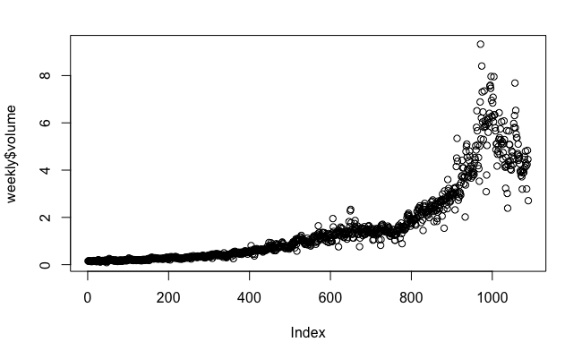

```r
plot(weekly$volume)
```

**examine the structure of the data**

```r
head(weekly)
```

|  | year | lag1 | lag2 | lag3 | lag4 | lag5 | volume | today | direction |
| --- | --- | --- | --- | --- | --- | --- | --- | --- | --- |
| 1 | 1990 | 0.816 | 1.572 | -3.936 | -0.229 | -3.484 | 0.1549760 | -0.270 | Down |
| 2 | 1990 | -0.270 | 0.816 | 1.572 | -3.936 | -0.229 | 0.1485740 | -2.576 | Down |
| 3 | 1990 | -2.576 | -0.270 | 0.816 | 1.572 | -3.936 | 0.1598375 | 3.514 | Up |
| 4 | 1990 | 3.514 | -2.576 | -0.270 | 0.816 | 1.572 | 0.1616300 | 0.712 | Up |
| 5 | 1990 | 0.712 | 3.514 | -2.576 | -0.270 | 0.816 | 0.1537280 | 1.178 | Up |
| 6 | 1990 | 1.178 | 0.712 | 3.514 | -2.576 | -0.270 | 0.1544440 | -1.372 | Down |

```r
str(weekly)
```

```
'data.frame':   1089 obs. of  9 variables:
 $ year     : num  1990 1990 1990 1990 1990 1990 1990 1990 1990 1990 ...
 $ lag1     : num  0.816 -0.27 -2.576 3.514 0.712 ...
 $ lag2     : num  1.572 0.816 -0.27 -2.576 3.514 ...
 $ lag3     : num  -3.936 1.572 0.816 -0.27 -2.576 ...
 $ lag4     : num  -0.229 -3.936 1.572 0.816 -0.27 ...
 $ lag5     : num  -3.484 -0.229 -3.936 1.572 0.816 ...
 $ volume   : num  0.155 0.149 0.16 0.162 0.154 ...
 $ today    : num  -0.27 -2.576 3.514 0.712 1.178 ...
 $ direction: Factor w/ 2 levels "Down","Up": 1 1 2 2 2 1 2 2 2 1 ...
```

```r
summary(weekly)
```

```
      year           lag1               lag2               lag3               lag4               lag5              volume            today          direction
 Min.   :1990   Min.   :-18.1950   Min.   :-18.1950   Min.   :-18.1950   Min.   :-18.1950   Min.   :-18.1950   Min.   :0.08747   Min.   :-18.1950   Down:484
 1st Qu.:1995   1st Qu.: -1.1540   1st Qu.: -1.1540   1st Qu.: -1.1580   1st Qu.: -1.1580   1st Qu.: -1.1660   1st Qu.:0.33202   1st Qu.: -1.1540   Up  :605
 Median :2000   Median :  0.2410   Median :  0.2410   Median :  0.2410   Median :  0.2380   Median :  0.2340   Median :1.00268   Median :  0.2410
 Mean   :2000   Mean   :  0.1506   Mean   :  0.1511   Mean   :  0.1472   Mean   :  0.1458   Mean   :  0.1399   Mean   :1.57462   Mean   :  0.1499
 3rd Qu.:2005   3rd Qu.:  1.4050   3rd Qu.:  1.4090   3rd Qu.:  1.4090   3rd Qu.:  1.4090   3rd Qu.:  1.4050   3rd Qu.:2.05373   3rd Qu.:  1.4050
 Max.   :2010   Max.   : 12.0260   Max.   : 12.0260   Max.   : 12.0260   Max.   : 12.0260   Max.   : 12.0260   Max.   :9.32821   Max.   : 12.0260
```

**quickly examine trends among variables**

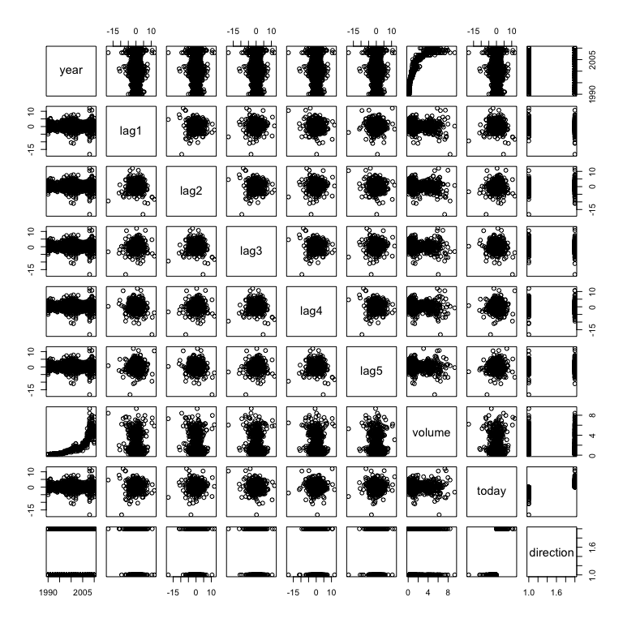

```r
pairs(weekly)
```

```r
cor(weekly[, -9])
```

```
              year         lag1        lag2        lag3         lag4         lag5      volume        today
year    1.00000000 -0.032289274 -0.03339001 -0.03000649 -0.031127923 -0.030519101  0.84194162 -0.032459894
lag1   -0.03228927  1.000000000 -0.07485305  0.05863568 -0.071273876 -0.008183096 -0.06495131 -0.075031842
lag2   -0.03339001 -0.074853051  1.00000000 -0.07572091  0.058381535 -0.072499482 -0.08551314  0.059166717
lag3   -0.03000649  0.058635682 -0.07572091  1.00000000 -0.075395865  0.060657175 -0.06928771 -0.071243639
lag4   -0.03112792 -0.071273876  0.05838153 -0.07539587  1.000000000 -0.075675027 -0.06107462 -0.007825873
lag5   -0.03051910 -0.008183096 -0.07249948  0.06065717 -0.075675027  1.000000000 -0.05851741  0.011012698
volume  0.84194162 -0.064951313 -0.08551314 -0.06928771 -0.061074617 -0.058517414  1.00000000 -0.033077783
today  -0.03245989 -0.075031842  0.05916672 -0.07124364 -0.007825873  0.011012698 -0.03307778  1.000000000
```

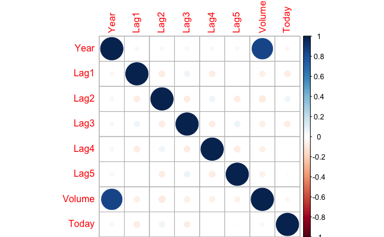

```r
corrplot(cor(Weekly[, -9]))
```

Let us fit a logistic model to begin with:

### b

```r
glm_fit_a = glm(direction ~ lag1 + lag2 + lag3 + lag4 + lag5 + volume,
              data = weekly, family = "binomial")
tidy(glm_fit_a)
```

| term | estimate | std.error | statistic | p.value |
| --- | --- | --- | --- | --- |
| (Intercept) | 0.26686414 | 0.08592961 | 3.1056134 | 0.001898848 |
| lag1 | -0.04126894 | 0.02641026 | -1.5626099 | 0.118144368 |
| lag2 | 0.05844168 | 0.02686499 | 2.1753839 | 0.029601361 |
| lag3 | -0.01606114 | 0.02666299 | -0.6023760 | 0.546923890 |
| lag4 | -0.02779021 | 0.02646332 | -1.0501409 | 0.293653342 |
| lag5 | -0.01447206 | 0.02638478 | -0.5485006 | 0.583348244 |
| volume | -0.02274153 | 0.03689812 | -0.6163330 | 0.537674762 |

```r
summary(glm_fit_a)
```

```
Call:
glm(formula = direction ~ lag1 + lag2 + lag3 + lag4 + lag5 +
    volume, family = "binomial", data = weekly)

Deviance Residuals:
    Min       1Q   Median       3Q      Max
-1.6949  -1.2565   0.9913   1.0849   1.4579

Coefficients:
            Estimate Std. Error z value Pr(>|z|)
(Intercept)  0.26686    0.08593   3.106   0.0019 **
lag1        -0.04127    0.02641  -1.563   0.1181
lag2         0.05844    0.02686   2.175   0.0296 *
lag3        -0.01606    0.02666  -0.602   0.5469
lag4        -0.02779    0.02646  -1.050   0.2937
lag5        -0.01447    0.02638  -0.549   0.5833
volume      -0.02274    0.03690  -0.616   0.5377
---
Signif. codes:  0 ‘***’ 0.001 ‘**’ 0.01 ‘*’ 0.05 ‘.’ 0.1 ‘ ’ 1

(Dispersion parameter for binomial family taken to be 1)

    Null deviance: 1496.2  on 1088  degrees of freedom
Residual deviance: 1486.4  on 1082  degrees of freedom
AIC: 1500.4

Number of Fisher Scoring iterations: 4
```

```r
# no intercept
glm_fit_b = glm(direction ~ 0 + lag1 + lag2 + lag3 +
                 lag4 + lag5 + volume, data = weekly,
               family = binomial)
summary(glm_fit_b)
```

```
Call:
glm(formula = direction ~ 0 + lag1 + lag2 + lag3 + lag4 + lag5 +
    volume, family = binomial, data = weekly)

Deviance Residuals:
   Min      1Q  Median      3Q     Max
-1.726  -1.191   1.033   1.148   1.553

Coefficients:
        Estimate Std. Error z value Pr(>|z|)
lag1   -0.032730   0.026177  -1.250   0.2112
lag2    0.068196   0.026685   2.556   0.0106 *
lag3   -0.008099   0.026447  -0.306   0.7594
lag4   -0.019420   0.026231  -0.740   0.4591
lag5   -0.006856   0.026230  -0.261   0.7938
volume  0.056925   0.026792   2.125   0.0336 *
---
Signif. codes:  0 ‘***’ 0.001 ‘**’ 0.01 ‘*’ 0.05 ‘.’ 0.1 ‘ ’ 1

(Dispersion parameter for binomial family taken to be 1)

    Null deviance: 1509.7  on 1089  degrees of freedom
Residual deviance: 1496.1  on 1083  degrees of freedom
AIC: 1508.1

Number of Fisher Scoring iterations: 4
```

```r
# changing the sequence of variables
glm_fit_c = glm(direction ~ lag2 + lag3 +
                 lag4 + lag5 + volume + lag1,
                data = weekly,
               family = binomial)
summary(glm_fit_c)
```

```
Call:
glm(formula = direction ~ lag2 + lag3 + lag4 + lag5 + volume +
    lag1, family = binomial, data = weekly)

Deviance Residuals:
    Min       1Q   Median       3Q      Max
-1.6949  -1.2565   0.9913   1.0849   1.4579

Coefficients:
            Estimate Std. Error z value Pr(>|z|)
(Intercept)  0.26686    0.08593   3.106   0.0019 **
lag2         0.05844    0.02686   2.175   0.0296 *
lag3        -0.01606    0.02666  -0.602   0.5469
lag4        -0.02779    0.02646  -1.050   0.2937
lag5        -0.01447    0.02638  -0.549   0.5833
volume      -0.02274    0.03690  -0.616   0.5377
lag1        -0.04127    0.02641  -1.563   0.1181
---
Signif. codes:  0 ‘***’ 0.001 ‘**’ 0.01 ‘*’ 0.05 ‘.’ 0.1 ‘ ’ 1

(Dispersion parameter for binomial family taken to be 1)

    Null deviance: 1496.2  on 1088  degrees of freedom
Residual deviance: 1486.4  on 1082  degrees of freedom
AIC: 1500.4

Number of Fisher Scoring iterations: 4
```

**number of weeks when marker was up/down**

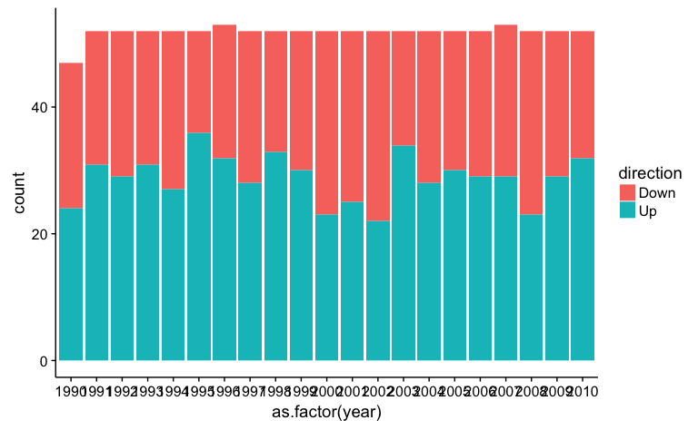

```r
ggplot(weekly, aes(x = as.factor(year), fill = direction)) +
  geom_bar()
```

```r
# Extract coefficients
tidy(coef(glm_fit_a))
```

| names | x |
| --- | --- |
| (Intercept) | 0.26686414 |
| lag1 | -0.04126894 |
| lag2 | 0.05844168 |
| lag3 | -0.01606114 |
| lag4 | -0.02779021 |
| lag5 | -0.01447206 |
| volume | -0.02274153 |

```r
summary(glm_fit_a$coefficients) # another way to extract coeff.
```

```
    Min.  1st Qu.   Median     Mean  3rd Qu.     Max.
-0.04127 -0.02527 -0.01606  0.02900  0.02198  0.26690
```

`type` tell glm to output prob in form of P(Y = 1|X)

response: on the scale of Y default: log-odds (default predictions are of log-odds (probabilities on logit scale)

```r
# Use predict function
glm.probs = predict(glm_fit_a, type = "response")
# type tell glm to output prob in form of P(Y = 1|X)
tidy(glm.probs[1:10])
```

| names | x |
| --- | --- |
| 1 | 0.6086249 |
| 2 | 0.6010314 |
| 3 | 0.5875699 |
| 4 | 0.4816416 |
| 5 | 0.6169013 |
| 6 | 0.5684190 |
| 7 | 0.5786097 |
| 8 | 0.5151972 |
| 9 | 0.5715200 |
| 10 | 0.5554287 |

```r
glm_fit_a$fitted.values[1:10]
```

```
        1         2         3         4         5         6         7         8         9        10
0.6086249 0.6010314 0.5875699 0.4816416 0.6169013 0.5684190 0.5786097 0.5151972 0.5715200 0.5554287
```

```r
df = data.frame(obs_dir = weekly[,"direction"],
                fitted = glm_fit_a$fitted.values, stringsAsFactors = FALSE)
df
```

|  | obs_dir | fitted |
| --- | --- | --- |
| 1 | Down | 0.6086249 |
| 2 | Down | 0.6010314 |
| 3 | Up | 0.5875699 |
| 4 | Up | 0.4816416 |
| 5 | Up | 0.6169013 |
| 6 | Down | 0.5684190 |
| 7 | Up | 0.5786097 |
| 8 | Up | 0.5151972 |
| 9 | Up | 0.5715200 |
| 10 | Down | 0.5554287 |

[output cut: 990 more lines]

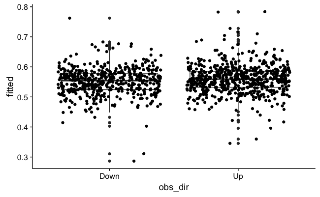

```r
ggplot(df, aes(obs_dir, fitted)) + geom_boxplot() + geom_jitter()
```

```r
df = mutate(df, fitted_dir = ifelse(fitted > 0.5, "Up", "Down"))
```

```r
filter(df, obs_dir == "Down", fitted_dir == "Up")

table(df$obs_dir, df$fitted_dir)
```

[output not shown]

```r
(507 + 145)/1250
```

```
[1] 0.5216
```

Section LDA

```r
p_load(MASS)
train = (Smarket$Year < 2005)
lda_fit = lda(Direction ~ Lag1 + Lag2, data = Smarket, subset = train)
print(lda_fit)
```

```
Call:
lda(Direction ~ Lag1 + Lag2, data = Smarket, subset = train)

Prior probabilities of groups:
    Down       Up
0.491984 0.508016

Group means:
            Lag1        Lag2
Down  0.04279022  0.03389409
Up   -0.03954635 -0.03132544

Coefficients of linear discriminants:
            LD1
Lag1 -0.6420190
Lag2 -0.5135293
```

$\beta_1$: -0.642 $\beta_2$: -0.513

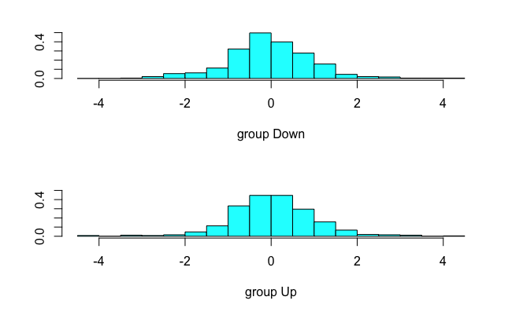

```r
plot(lda_fit)
```

```r
smarket_2005 = Smarket [!train, ]
pred_lda = predict(lda_fit, newdata = smarket_2005)
class_lda = pred_lda$class
table(class_lda, smarket_2005$Direction)
```

```
class_lda Down  Up
     Down   35  35
     Up     76 106
```

```r
mean(class_lda == smarket_2005$Direction)
```

```
[1] 0.5595238
```

# ’ KNN

```r
p_load(class)
# X: predictors
train.X = cbind(Smarket$Lag1, Smarket$Lag2)[train ,]
test.X = cbind(Smarket$Lag1, Smarket$Lag2)[!train, ]
# Y: response
train.Direction = Smarket$Direction[train]
for(k in 1:4){
  set.seed(1)
  cat("working with k:", k)
  #           training  test    what is the response
  knn.pred = knn(train.X, test.X, train.Direction, k = )
  table(knn.pred, smarket_2005$Direction)
  mean(knn.pred == smarket_2005$Direction)
}
```

```
working with k: 1working with k: 2working with k: 3working with k: 4
```

Using LDA with MLR

```r
p_load(mlr)
data(iris)
print(iris)
```

| Sepal.Length | Sepal.Width | Petal.Length | Petal.Width | Species |
| --- | --- | --- | --- | --- |
| 5.1 | 3.5 | 1.4 | 0.2 | setosa |
| 4.9 | 3.0 | 1.4 | 0.2 | setosa |
| 4.7 | 3.2 | 1.3 | 0.2 | setosa |
| 4.6 | 3.1 | 1.5 | 0.2 | setosa |
| 5.0 | 3.6 | 1.4 | 0.2 | setosa |
| 5.4 | 3.9 | 1.7 | 0.4 | setosa |
| 4.6 | 3.4 | 1.4 | 0.3 | setosa |
| 5.0 | 3.4 | 1.5 | 0.2 | setosa |
| 4.4 | 2.9 | 1.4 | 0.2 | setosa |
| 4.9 | 3.1 | 1.5 | 0.1 | setosa |

[output cut: 140 more lines]

```r
## Define the task
task = makeClassifTask(id = "tutorial", data = iris, target = "Species")
## Define the learner
lrn = makeLearner("classif.lda")
## Define the resampling strategy
rdesc = makeResampleDesc(method = "CV", stratify = TRUE)
## Do the resampling
r = resample(learner = lrn, task = task, resampling = rdesc, show.info = FALSE)
## Get the mean misclassification error
print(r)
```

```
Resample Result
Task: tutorial
Learner: classif.lda
mmce.aggr: 0.03
mmce.mean: 0.03
mmce.sd: 0.06
Runtime: 0.197826
```

```r
library(MASS)
fit.lda <- lda(direction ~ lag2,
               data = weekly,
               subset = train)
fit.lda

pred.lda <- predict(fit.lda, weekly.20092010)
table(pred.lda$class, direction.20092010)
```

[output not shown]

## Q 11.

```r
attach(Auto)
mpg01 <- rep(0, length(mpg))
mpg01[mpg > median(mpg)] <- 1
Auto <- data.frame(Auto, mpg01)
```

```r
cor(Auto[, -9])
```

```
                    mpg  cylinders displacement horsepower     weight acceleration       year     origin      mpg01    mpg01.1
mpg           1.0000000 -0.7776175   -0.8051269 -0.7784268 -0.8322442    0.4233285  0.5805410  0.5652088  0.8369392  0.8369392
cylinders    -0.7776175  1.0000000    0.9508233  0.8429834  0.8975273   -0.5046834 -0.3456474 -0.5689316 -0.7591939 -0.7591939
displacement -0.8051269  0.9508233    1.0000000  0.8972570  0.9329944   -0.5438005 -0.3698552 -0.6145351 -0.7534766 -0.7534766
horsepower   -0.7784268  0.8429834    0.8972570  1.0000000  0.8645377   -0.6891955 -0.4163615 -0.4551715 -0.6670526 -0.6670526
weight       -0.8322442  0.8975273    0.9329944  0.8645377  1.0000000   -0.4168392 -0.3091199 -0.5850054 -0.7577566 -0.7577566
acceleration  0.4233285 -0.5046834   -0.5438005 -0.6891955 -0.4168392    1.0000000  0.2903161  0.2127458  0.3468215  0.3468215
year          0.5805410 -0.3456474   -0.3698552 -0.4163615 -0.3091199    0.2903161  1.0000000  0.1815277  0.4299042  0.4299042
origin        0.5652088 -0.5689316   -0.6145351 -0.4551715 -0.5850054    0.2127458  0.1815277  1.0000000  0.5136984  0.5136984
mpg01         0.8369392 -0.7591939   -0.7534766 -0.6670526 -0.7577566    0.3468215  0.4299042  0.5136984  1.0000000  1.0000000
mpg01.1       0.8369392 -0.7591939   -0.7534766 -0.6670526 -0.7577566    0.3468215  0.4299042  0.5136984  1.0000000  1.0000000
```

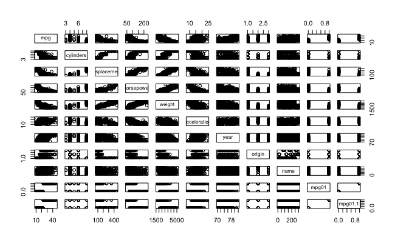

```r
pairs(Auto)
```

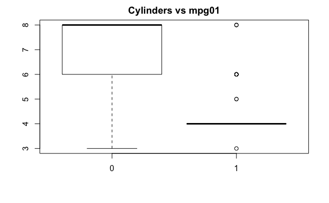

```r
boxplot(cylinders ~ mpg01, data = Auto, main = "Cylinders vs mpg01")
```

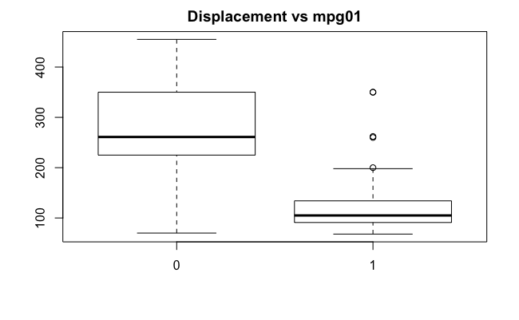

```r
boxplot(displacement ~ mpg01, data = Auto, main = "Displacement vs mpg01")
```

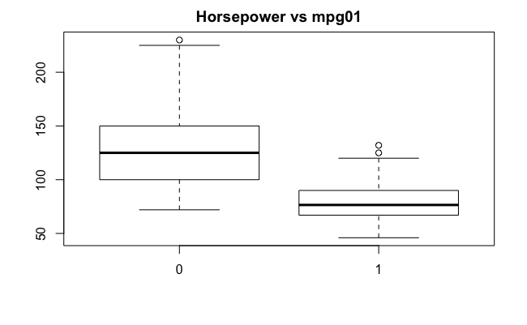

```r
boxplot(horsepower ~ mpg01, data = Auto, main = "Horsepower vs mpg01")
```

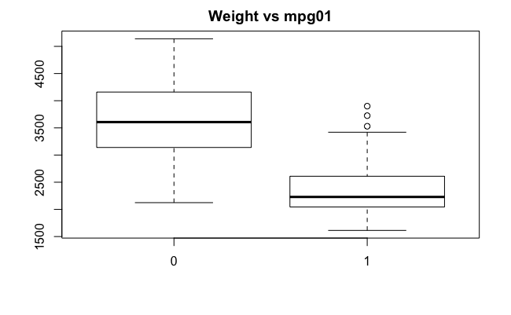

```r
boxplot(weight ~ mpg01, data = Auto, main = "Weight vs mpg01")
```

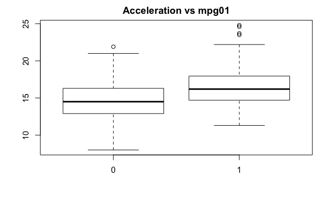

```r
boxplot(acceleration ~ mpg01, data = Auto, main = "Acceleration vs mpg01")
```

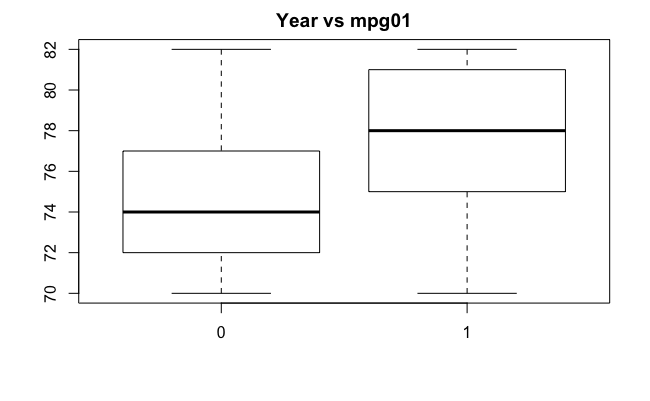

```r
boxplot(year ~ mpg01, data = Auto, main = "Year vs mpg01")
```

c We may conclude that there exists some association between “mpg01” and “cylinders”, “weight”, “displacement” and “horsepower”. Split the data into a training set and a test set.

```r
train = (year%%2 == 0)  # if the year is even
test = !train
Auto.train = Auto[train, ]
Auto.test = Auto[test, ]
mpg01.test = mpg01[test]
```

4. Perform LDA on the training data in order to predict “mpg01” using the variables that seemed most associated with “mpg01” in (b). What is the test error of the model obtained ?

```r
p_load(MASS)
# LDA
library(MASS)
lda.fit = lda(mpg01 ~ cylinders + weight + displacement + horsepower,
              data = Auto,
    subset = train)
lda.pred = predict(lda.fit, Auto.test)
mean(lda.pred$class != mpg01.test)
```

```
[1] 0.1263736
```

```r
# QDA
qda.fit = qda(mpg01 ~ cylinders + weight + displacement + horsepower, data = Auto,
    subset = train)
qda.pred = predict(qda.fit, Auto.test)
mean(qda.pred$class != mpg01.test)
```

```
[1] 0.1318681
```

6. logistic

```r
# Logistic regression
glm.fit = glm(mpg01 ~ cylinders + weight + displacement + horsepower, data = Auto,
    family = binomial, subset = train)
glm.probs = predict(glm.fit, Auto.test, type = "response")
glm.pred = rep(0, length(glm.probs))
glm.pred[glm.probs > 0.5] = 1
mean(glm.pred != mpg01.test)
```

```
[1] 0.1208791
```

7. KNN

```r
library(class)
train.X = cbind(cylinders, weight, displacement, horsepower)[train, ]
test.X = cbind(cylinders, weight, displacement, horsepower)[test, ]
train.mpg01 = mpg01[train]
set.seed(1)

# KNN(k=1)
knn.pred = knn(train.X, test.X, train.mpg01, k = 1)
mean(knn.pred != mpg01.test)

# KNN(k=10)
knn.pred = knn(train.X, test.X, train.mpg01, k = 10)
mean(knn.pred != mpg01.test)

# KNN(k=100)
knn.pred = knn(train.X, test.X, train.mpg01, k = 100)
mean(knn.pred != mpg01.test)
```

[output not shown]